# Weekly Report

Jose Zayas

2026-09-25

# SLE Prevalence vs Dengue Burden

## Scatter Log-Log

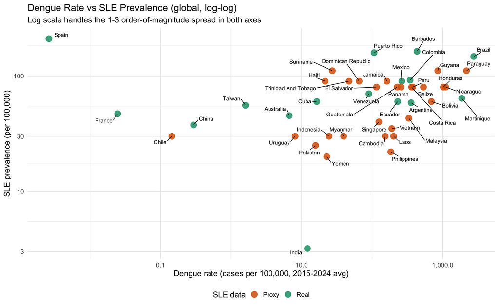

## Scatter — Linear version

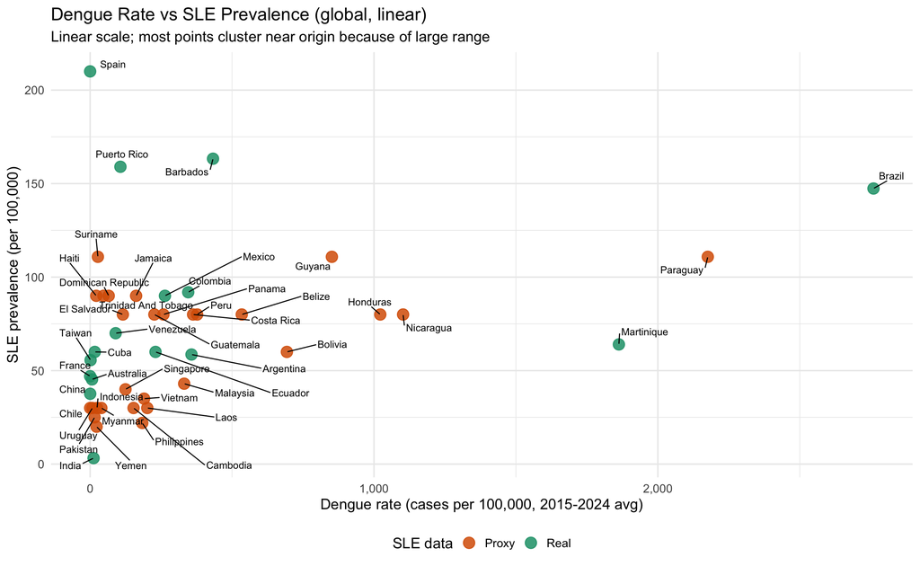

# Faceted Scatter by Region

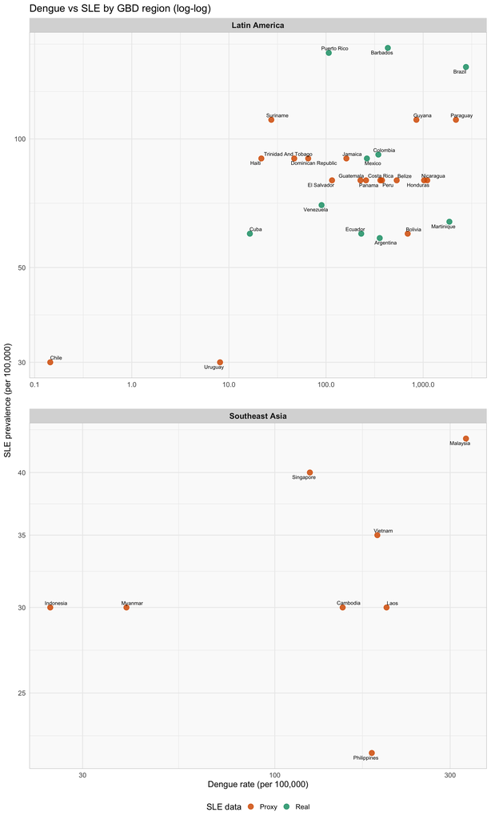

## Summary Table

Countries in analysis

| Country | Region | Dengue /100k | SLE /100k | Source | Tier |
| --- | --- | --- | --- | --- | --- |
| TAIWAN | East Asia | 1.6 | 55.60 | Chiu & Lai 2010 | Real |
| CHINA | East Asia | 0.3 | 37.60 | Zou 2014 (Anhui) | Real |
| FRANCE | Europe | 0.0 | 47.00 | Arnaud 2014 | Real |
| SPAIN | Europe | 0.0 | 210.00 | Cortes Verdu 2020 | Real |
| AUSTRALIA | High-income | 6.7 | 45.30 | Bossingham 2003 | Real |
| BRAZIL | Latin America | 2759.7 | 147.37 | Tian 2023 (ARD) | Real |
| PARAGUAY | Latin America | 2175.9 | 110.85 | Tian 2023 (Tropical LA proxy) | Proxy |
| MARTINIQUE | Latin America | 1862.8 | 64.00 | Deligny 2002 | Real |
| NICARAGUA | Latin America | 1102.5 | 80.00 | Tian 2023 (Central LA proxy) | Proxy |
| HONDURAS | Latin America | 1022.2 | 80.00 | Tian 2023 (Central LA proxy) | Proxy |
| GUYANA | Latin America | 851.7 | 110.85 | Tian 2023 (Tropical LA proxy) | Proxy |
| BOLIVIA | Latin America | 693.2 | 60.00 | Tian 2023 (Andean LA proxy) | Proxy |
| BELIZE | Latin America | 534.2 | 80.00 | Tian 2023 (Central LA proxy) | Proxy |
| BARBADOS | Latin America | 432.9 | 163.31 | Tian 2023 (ARD) | Real |
| PERU | Latin America | 377.1 | 80.00 | Tian 2023 (Central LA proxy) | Proxy |
| COSTA RICA | Latin America | 362.6 | 80.00 | Tian 2023 (Central LA proxy) | Proxy |
| ARGENTINA | Latin America | 357.2 | 58.60 | Scolnik 2014 (Buenos Aires) | Real |
| COLOMBIA | Latin America | 345.6 | 91.90 | Fernandez-Avila 2019 (crude) | Real |
| MEXICO | Latin America | 263.6 | 90.00 | Pelaez-Ballestas 2011 | Real |
| PANAMA | Latin America | 258.2 | 80.00 | Tian 2023 (Central LA proxy) | Proxy |
| ECUADOR | Latin America | 230.4 | 60.00 | Guevara-Pacheco 2016 (Cuenca) | Real |
| GUATEMALA | Latin America | 226.3 | 80.00 | Tian 2023 (Central LA proxy) | Proxy |
| JAMAICA | Latin America | 162.0 | 90.00 | Tian 2023 (Caribbean proxy) | Proxy |
| EL SALVADOR | Latin America | 115.3 | 80.00 | Tian 2023 (Central LA proxy) | Proxy |
| PUERTO RICO | Latin America | 106.7 | 159.00 | Molina 2007 | Real |
| VENEZUELA | Latin America | 90.0 | 70.00 | Granados 2015 (Monagas) | Real |
| DOMINICAN REPUBLIC | Latin America | 65.5 | 90.00 | Tian 2023 (Caribbean proxy) | Proxy |
| TRINIDAD AND TOBAGO | Latin America | 47.1 | 90.00 | Tian 2023 (Caribbean proxy) | Proxy |
| SURINAME | Latin America | 27.3 | 110.85 | Tian 2023 (Tropical LA proxy) | Proxy |
| HAITI | Latin America | 21.6 | 90.00 | Tian 2023 (Caribbean proxy) | Proxy |
| CUBA | Latin America | 16.4 | 60.00 | Reyes-Llerena 2009 (Havana) | Real |
| URUGUAY | Latin America | 8.1 | 30.00 | Tian 2023 (Southern LA proxy) | Proxy |
| CHILE | Latin America | 0.1 | 30.00 | Tian 2023 (Southern LA proxy) | Proxy |
| YEMEN | Middle East | 22.7 | 20.00 | Regional proxy (MENA) | Proxy |
| PAKISTAN | South Asia | 15.8 | 25.00 | Regional proxy (South Asia) | Proxy |
| INDIA | South Asia | 12.1 | 3.20 | Chatterjee 2023 | Real |
| MALAYSIA | Southeast Asia | 331.2 | 43.00 | Regional proxy (SE Asia) | Proxy |
| LAOS | Southeast Asia | 201.4 | 30.00 | Regional proxy (SE Asia) | Proxy |
| VIETNAM | Southeast Asia | 190.1 | 35.00 | Regional proxy (SE Asia) | Proxy |
| PHILIPPINES | Southeast Asia | 183.6 | 22.00 | Regional proxy (SE Asia) | Proxy |
| CAMBODIA | Southeast Asia | 153.0 | 30.00 | Regional proxy (SE Asia) | Proxy |
| SINGAPORE | Southeast Asia | 124.6 | 40.00 | Regional proxy (SE Asia) | Proxy |
| MYANMAR | Southeast Asia | 39.5 | 30.00 | Regional proxy (SE Asia) | Proxy |
| INDONESIA | Southeast Asia | 24.5 | 30.00 | Regional proxy (SE Asia) | Proxy |

# MicroRNAs at the Interface of Dengue Infection and Systemic Lupus Erythematosus: A Focus on miR-21-5p

## 1. Introduction to MicroRNAs

MicroRNAs (miRNAs) are a class of small non-coding RNAs, approximately 18–25 nucleotides in length, that function as key post-transcriptional regulators of gene expression. Following transcription by RNA polymerase II and sequential processing by the RNase III enzymes Drosha and Dicer, mature miRNAs are incorporated into the RNA-induced silencing complex (RISC). Within RISC, miRNAs bind to complementary sequences—predominantly within the 3′-untranslated regions (3′UTR)—of specific messenger RNAs (mRNAs), thereby preventing translational events through either mRNA degradation or translational repression. Each miRNA is capable of regulating the expression of several, perhaps even hundreds, of target genes, and they are involved in essential biological processes including embryonic development, immune response, inflammation, oncogenesis, and cellular growth and proliferation.

# 2. Viral Infections and miRNAs: The Case of Dengue Virus

The involvement of miRNAs in viral infections has been extensively documented. Mutations in the main catalytic components of the RNA interference (RNAi) pathway lead to increased replication of several viruses, including dengue virus (DENV), vesicular stomatitis virus, influenza A virus, and human immunodeficiency virus in mammalian cells

Two independent studies have extensively profiled miRNA expressions in the blood of dengue patients, consistently demonstrating a significant number of differentially expressed miRNAs in response to infection. Tambyah et al. identified 348 differentially expressed miRNAs, with 17 miRNAs capable of distinguishing mild dengue from severe dengue with complications. Notably, **miR-24-1-5p**, **miR-512-5p**, and **miR-4640-3p** distinguished mild dengue from cases with liver complications, **while miR-383** was significantly upregulated in mild dengue compared to severe dengue with fluid accumulation. Ouyang et al. (2016) found 12 downregulated and 41 upregulated miRNAs in the sera of DENV-1 patients, with **hsa-miR-21-5p**, **hsa-miR-146a-5p**, **hsa-miR-590-5p**, **hsa-miR-188-5p**, and **hsa-miR-152-3p** identified as promising non-invasive molecular markers for detecting DENV infection.

miRNAs can directly target the viral genome to inhibit DENV replication. The first evidence was provided by miR-548 g-3p, which binds to the Stem Loop A promoter in the 5′UTR, a key element for DENV RNA synthesis, thereby downregulating replication of all four DENV serotypes. Similarly, miR-133a, miR-484, and miR-744 target the 3′UTR of the DENV genome, specifically the 3′ stem loop involved in genome circularization and viral viability. In the mosquito vector, miR-252 targets the DENV-2 E gene, suppressing viral replication.

miRNAs also modulate host factors to inhibit or facilitate DENV replication. Let-7c protects infected cells from oxidative stress and inflammation by targeting BACH1. miR-30e* enhances the host antiviral immune response by targeting IκBα, leading to NF-κB activation and increased IFN-β expression. The miR-34 family suppresses Wnt signaling, thereby increasing type I IFN and interferon-stimulated gene expression. miR-223 inhibits DENV-2 replication by dampening stathmin 1 expression.

Conversely, miRNAs can also favor viral replication. miR-146a enhances DENV-2 replication by targeting TRAF6 and dampening IFN-β production. **miR-21 promotes DENV-2 replication, although the exact mechanism remains unclear; it may directly target the NS1 protein sequence**.

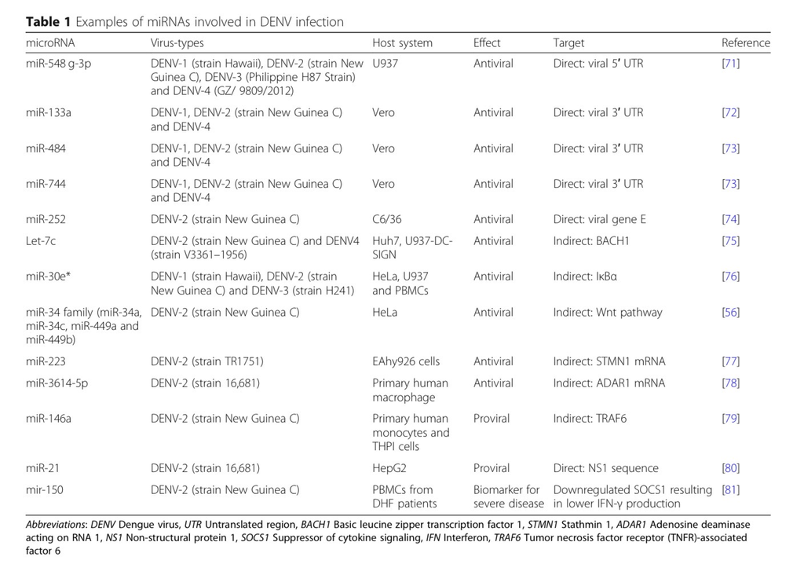

## 3. Autoimmunity and miRNAs:The Case of Systemic Lupus Erythematosus

Autoimmune diseases arise from a breakdown of self-tolerance, leading to immune-mediated damage of host tissues. miRNAs have emerged as critical regulators of immune cell development, activation, and function, and their dysregulation contributes to autoimmune pathogenesis. Systemic lupus erythematosus (SLE) is a prototypical systemic autoimmune disease characterized by loss of tolerance to nuclear antigens, immune complex deposition, and multi-organ damage.

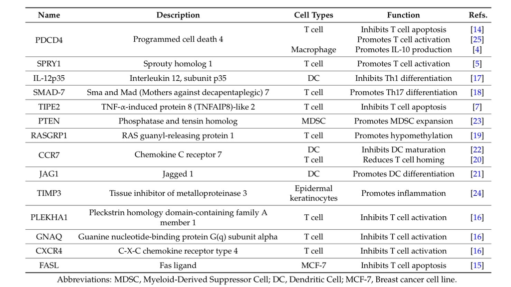

In SLE, numerous miRNAs exhibit altered expression profiles. **miR-21** is significantly **upregulated** in the **plasma, peripheral blood mononuclear cells (PBMC), B cells, and CD4+ T cells** of SLE patients. This upregulation correlates strongly with disease activity. **Silencing of miR-21 reverses the activated phenotype of T cells from SLE patients, while overexpression of miR-21 in normal T cells induces an activated phenotype through downregulation of PDCD4**. miR-21 also promotes T cell hypomethylation by repressing RASGRP1, leading to downregulation of DNA methyltransferase 1 and overexpression of autoimmune-associated methylation-sensitive genes such as CD70 and LFA-1. Furthermore, the miR-21-TIPE2 axis plays important roles in SLE pathogenesis, as TIPE2 expression is downregulated in PBMCs from SLE patients.

## 4. Points of Interest Between DENV and miR-21-5p

The intersection of DENV infection and miR-21-5p presents several intriguing points of clinical and biological relevance:

### 4.1 Diagnostic Potential:

Ouyang et al. (2016) identified hsa-miR-21-5p as one of five promising non-invasive molecular markers for detecting DENV infection. **miR-21-5p was significantly upregulated in the sera of DENV-1 patients** compared to healthy controls and demonstrated high sensitivity and specificity as an indicator of DENV infection. **Additionally, miR-21-5p levels correlated with the number of leukocytes and neutrophils**, suggesting its potential utility in monitoring disease progression.

### 4.2 Proviral Role:

miR-21 appears to play a proviral role in DENV infection. Kanokudom et al. (2017) found that miR-21 expression was significantly increased upon DENV-2 infection, and this upregulation promoted viral replication. **Treatment with an anti-miR-21 (AMO-21) prior to DENV infection in HepG2 cells resulted in a significant reduction in DENV-2 production**, indicating that miR-21 plays a crucial role in DENV-2 replication.

### 4.3 Inflammatory Modulation:

miR-21 is functionally involved in inflammation and cell proliferation. During DENV infection, the cytokine storm—a systemic inflammatory response syndrome—is a hallmark of severe dengue. miR-21 promotes inflammation and plays important roles during the pathogenesis of autoimmune diseases.

## 5. miR-21-5p and Systemic Lupus Erythematosus

miR-21-5p (often referred to simply as miR-21) plays multifaceted roles in SLE pathogenesis, affecting both innate and adaptive immune responses:

### 5.1 T Cell Activation and Apoptosis:

miR-21 is significantly increased in activated CD4+ T lymphocytes and promotes ERK and JNK signaling through downregulation of Sprouty1, thereby augmenting T cell responses. **miR-21 also inhibits T cell apoptosis** by targeting tumor suppressors including PDCD4, TIPE2, and FASL. **In SLE, miR-21 upregulation correlates with disease activity, and silencing miR-21 reverses the activated phenotype of SLE T cells.**

### 5.2 DNA Hypomethylation:

Increased miR-21 expression in CD4+ T cells from lupus patients and lupus-prone MRL/lpr mice promotes cell hypomethylation by repressing RASGRP1, leading to downregulation of DNA methyltransferase 1 and overexpression of autoimmune-associated methylation-sensitive genes such as CD70 and LFA-1. **This mechanism is particularly relevant to SLE, where defective T cell DNA methylation contributes to autoreactivity.**

### 5.3 Myeloid Cell Function:

**miR-21 negatively regulates TLR4 signaling through targeting PDCD4 in macrophages, promoting IL-10 expression and blocking NF-κB activity.** miR-21 also enhances the frequency of cytokine-induced myeloid-derived suppressor cells via targeting PTEN and promotes dendritic cell differentiation through downregulation of JAG1.